# Lab09

Author

Heloisa Franco Gomes - 187932

## Configuração

```python
import numpy as np
import pandas as pd
from plotnine import *
from plotnine.data import diamonds
```

## Questão 1

```python
print(diamonds.shape)
diamonds.head()
```

```
(53940, 10)
```

|  | carat | cut | color | clarity | depth | table | price | x | y | z |
| --- | --- | --- | --- | --- | --- | --- | --- | --- | --- | --- |
| 0 | 0.23 | Ideal | E | SI2 | 61.5 | 55.0 | 326 | 3.95 | 3.98 | 2.43 |
| 1 | 0.21 | Premium | E | SI1 | 59.8 | 61.0 | 326 | 3.89 | 3.84 | 2.31 |
| 2 | 0.23 | Good | E | VS1 | 56.9 | 65.0 | 327 | 4.05 | 4.07 | 2.31 |
| 3 | 0.29 | Premium | I | VS2 | 62.4 | 58.0 | 334 | 4.20 | 4.23 | 2.63 |
| 4 | 0.31 | Good | J | SI2 | 63.3 | 58.0 | 335 | 4.34 | 4.35 | 2.75 |

```python
diamonds.info()
```

```
<class 'pandas.DataFrame'>
RangeIndex: 53940 entries, 0 to 53939
Data columns (total 10 columns):
 #   Column   Non-Null Count  Dtype
---  ------   --------------  -----
 0   carat    53940 non-null  float64
 1   cut      53940 non-null  category
 2   color    53940 non-null  category
 3   clarity  53940 non-null  category
 4   depth    53940 non-null  float64
 5   table    53940 non-null  float64
 6   price    53940 non-null  int64
 7   x        53940 non-null  float64
 8   y        53940 non-null  float64
 9   z        53940 non-null  float64
dtypes: category(3), float64(6), int64(1)
memory usage: 3.0 MB
```

```python
diamonds["cut"] = pd.Categorical(diamonds["cut"],
    categories=["Fair","Good","Very Good","Premium","Ideal"], ordered=True)
diamonds["color"] = pd.Categorical(diamonds["color"],
    categories=["D","E","F","G","H","I","J"], ordered=True)
diamonds["clarity"] = pd.Categorical(diamonds["clarity"],
    categories=["I1","SI2","SI1","VS2","VS1","VVS2","VVS1","IF"], ordered=True)
```

### Exploração com SQL via DuckDB

```python
import duckdb
con = duckdb.connect()
con.register("diamonds", diamonds)
con.execute("""
    SELECT cut,
           COUNT(*)             AS n,
           ROUND(AVG(price), 0) AS preco_medio,
           ROUND(AVG(carat), 2) AS carat_medio
    FROM diamonds
    GROUP BY cut
    ORDER BY preco_medio DESC
""").df()
```

|  | cut | n | preco_medio | carat_medio |
| --- | --- | --- | --- | --- |
| 0 | Premium | 13791 | 4584.0 | 0.89 |
| 1 | Fair | 1610 | 4359.0 | 1.05 |
| 2 | Very Good | 12082 | 3982.0 | 0.81 |
| 3 | Good | 4906 | 3929.0 | 0.85 |
| 4 | Ideal | 21551 | 3458.0 | 0.70 |

## Questão 2

Primeiro, um gráfico simples:

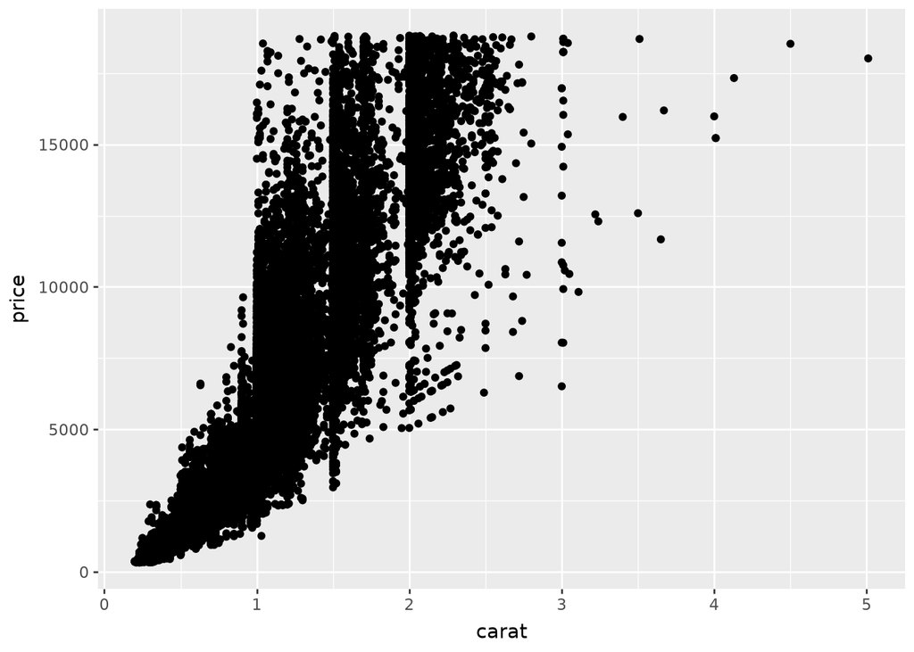

```python
p_base = ggplot(diamonds, aes("carat", "price")) + geom_point()
p_base
```

Gráfico melhorado:

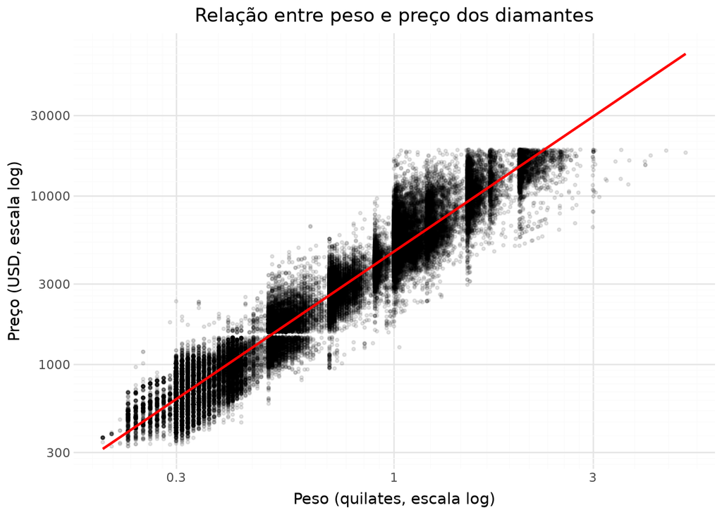

```python
p2 = (
    ggplot(diamonds, aes("carat", "price"))
    + geom_point(alpha=0.1, size=0.8)
    + geom_smooth(method="lm", color="red")
    + scale_x_log10()
    + scale_y_log10()
    + labs(title="Relação entre peso e preço dos diamantes",
           x="Peso (quilates, escala log)",
           y="Preço (USD, escala log)")
    + theme_minimal()
)
p2
```

**Resposta:** Para produzir um gráfico de boa qualidade, tomei as seguintes ações: (i) usei um gráfico de dispersão, adequado para duas variáveis numéricas; (ii) apliquei transparência e reduzi o tamanho dos pontos para mitigar o *overplotting*, já que são mais de 53 mil observações; (iii) usei escala logarítmica nos dois eixos, pois na escala original a relação é curva e a variabilidade do preço cresce com o peso; (iv) adicionei uma reta de tendência; (v) incluí título, rótulos com unidades e tema limpo. O principal achado é uma associação positiva e forte: diamantes mais pesados são mais caros. A relação é não linear na escala original, mas aproximadamente linear em log-log, sugerindo uma relação do tipo potência.

## Questão 3

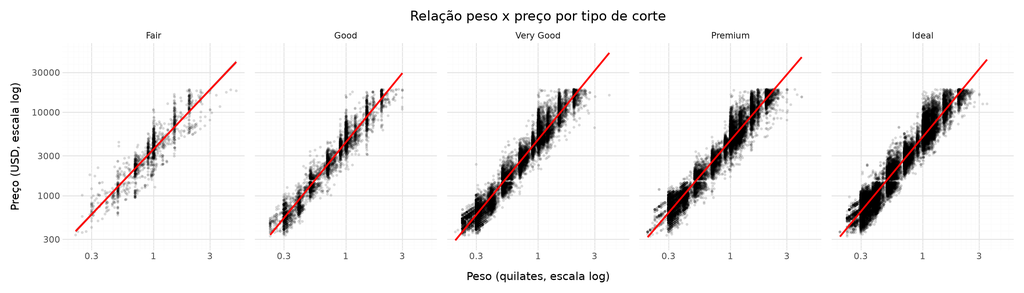

```python
p3 = (
    ggplot(diamonds, aes("carat", "price"))
    + geom_point(alpha=0.1, size=0.6)
    + geom_smooth(method="lm", color="red")
    + facet_wrap("~cut", nrow=1)
    + scale_x_log10()
    + scale_y_log10()
    + labs(title="Relação peso x preço por tipo de corte",
           x="Peso (quilates, escala log)", y="Preço (USD, escala log)")
    + theme_minimal()
    + theme(figure_size=(14, 4))
)
p3
```

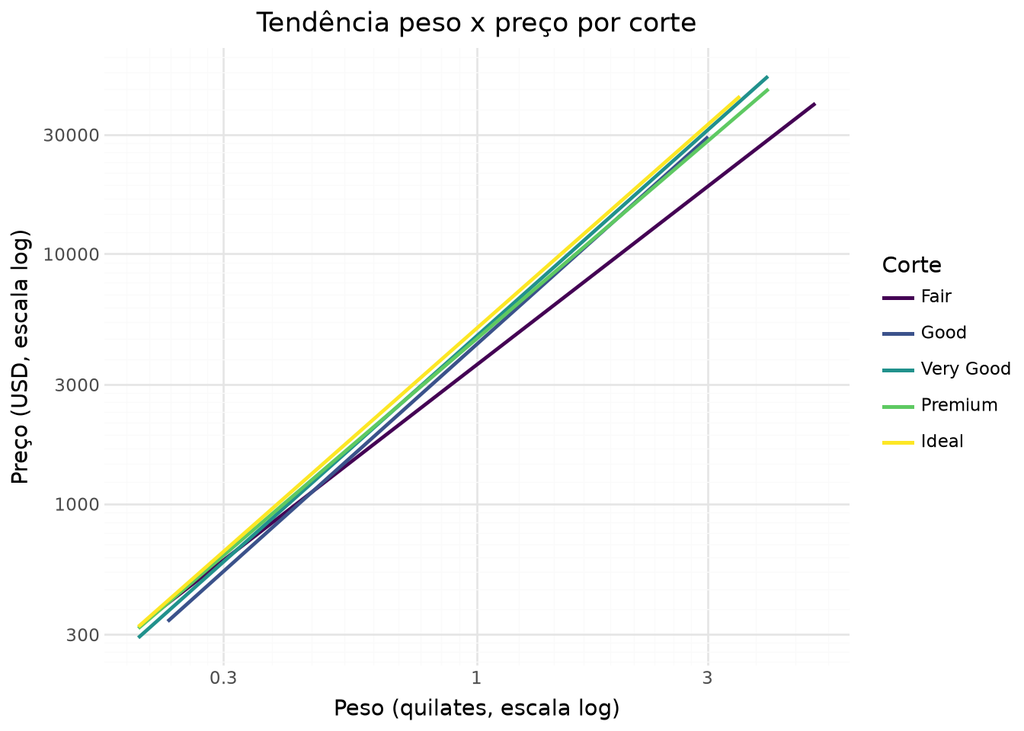

```python
p3b = (
    ggplot(diamonds, aes("carat", "price", color="cut"))
    + geom_smooth(method="lm", se=False)
    + scale_x_log10()
    + scale_y_log10()
    + labs(title="Tendência peso x preço por corte",
           x="Peso (quilates, escala log)", y="Preço (USD, escala log)",
           color="Corte")
    + theme_minimal()
)
p3b
```

```python
d = diamonds.assign(lcarat=np.log(diamonds["carat"]),
                    lprice=np.log(diamonds["price"]))
d.groupby("cut", observed=True).apply(
    lambda g: g["lcarat"].corr(g["lprice"]))
```

```
cut
Fair         0.908513
Good         0.968751
Very Good    0.971675
Premium      0.969758
Ideal        0.966188
dtype: float64
```

**Resposta:** Sim, o padrão geral se repete em todos os cortes: há associação positiva e forte entre peso e preço, com relação aproximadamente linear em log-log. A correlação entre log(peso) e log(preço) é alta em todos os cortes (≥ 0,96), com exceção de *Fair* (0,91), que tem menos observações e maior dispersão. Além disso, o preço médio não segue a ordem de qualidade do corte: *Ideal* tem o menor preço médio (US$ 3.458) e peso médio de 0,70 ct, enquanto *Fair* tem 1,05 ct. Isso mostra que o peso domina o preço e que o corte tem efeito secundário.

## Questão 4

Filtragem: só traço reta de tendência em combinações com pelo menos 10 diamantes.

```python
d4 = diamonds.copy()
d4["n_grupo"] = d4.groupby(["cut", "color", "clarity"],
                           observed=True)["price"].transform("size")
d4_ok = d4[d4["n_grupo"] >= 10]

print("Combinações possíveis:", 5 * 7 * 8)
print("Combinações com >= 10 diamantes:",
      d4_ok.groupby(["cut", "color", "clarity"], observed=True).ngroups)
```

```
Combinações possíveis: 280
Combinações com >= 10 diamantes: 246
```

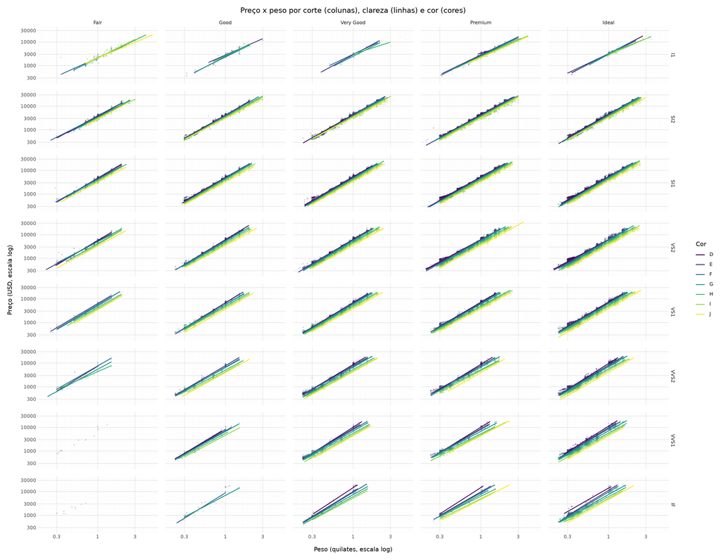

```python
p4 = (
    ggplot(d4, aes("carat", "price", color="color"))
    + geom_point(alpha=0.15, size=0.4)
    + geom_smooth(data=d4_ok, method="lm", se=False, size=0.8)
    + facet_grid("clarity ~ cut")
    + scale_x_log10()
    + scale_y_log10()
    + labs(title="Preço x peso por corte (colunas), clareza (linhas) e cor (cores)",
           x="Peso (quilates, escala log)", y="Preço (USD, escala log)",
           color="Cor")
    + theme_minimal()
    + theme(figure_size=(18, 14))
)
p4
```

**Dificuldades:** (i) são 5 × 7 × 8 = 280 combinações de corte, cor e clareza, o que impede mostrar tudo em um único painel; foi necessário usar facetas para duas variáveis (corte e clareza) e cor para a terceira; (ii) mesmo assim, o gráfico fica denso, com 40 painéis; (iii) o *overplotting* é severo, exigindo transparência e escala logarítmica; (iv) muitas combinações têm poucos diamantes (algumas apenas um), o que torna as retas instáveis, então tracei retas apenas para combinações com pelo menos 10 observações; (v) diferenciar 7 níveis de cor numa paleta é difícil, e comparar painéis distantes exige esforço visual.

**Conclusão:** A relação entre preço e peso **não é exatamente a mesma** em todas as configurações. A forma geral se mantém (positiva e aproximadamente linear em log-log), mas o nível das retas muda: para o mesmo peso, diamantes com melhor clareza e melhor cor tendem a custar mais. O peso é o fator dominante, e clareza e cor deslocam o nível do preço.